# Homework 1: Example key

Rebecca Ferrell

April 6, 2016

## Data description

The `swiss` data contain several variables pertaining to socioeconomic information of 47 French-speaking provinces of Switzerland in 1888. These include:

- **Fertility**: “a common standardized fertility measure”
- **Agriculture**: percent of males involved in agriculture as occupation
- **Examination** : percent of draftees receiving highest mark on army examination
- **Education**: percent of draftees having education beyond primary school
- **Catholic**: percent of the population that is Catholic (as opposed to Protestant)
- **Infant Mortality**: percentage of live births who live less than 1 year.

Example observations within the Swiss data

|  | Fertility | Agriculture | Examination | Education | Catholic | Infant.Mortality |
| --- | --- | --- | --- | --- | --- | --- |
| **Courtelary** | 80.2 | 17 | 15 | 12 | 9.96 | 22.2 |
| **Delemont** | 83.1 | 45.1 | 6 | 9 | 84.84 | 22.2 |
| **Franches-Mnt** | 92.5 | 39.7 | 5 | 5 | 93.4 | 20.2 |
| **Moutier** | 85.8 | 36.5 | 12 | 7 | 33.77 | 20.3 |
| **Neuveville** | 76.9 | 43.5 | 17 | 15 | 5.16 | 20.6 |
| **Porrentruy** | 76.1 | 35.3 | 9 | 7 | 90.57 | 26.6 |

We can observe joint relationships between these variables in the figure below:

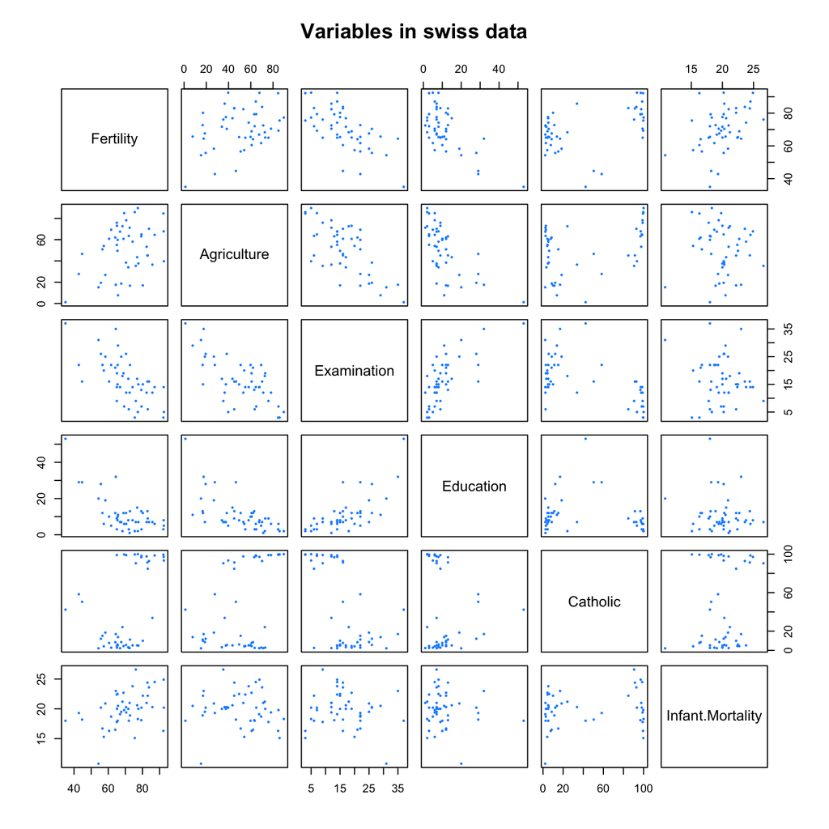

## Examination

Among other things, we observe that the `Examination` variable — the percent of draftees receiving the highest mark on their army exams — has strong negative associations with fertility (Pearson correlation = -0.65), agriculture (correlation = -0.69), and percent Catholic (correlation = -0.57), and a strong positive association with post-primary draftee education rates (correlation = 0.7). It is weakly associated with infant mortality rates (correlation = -0.11).

Looking more closely into this variable, we see that the mean percentage of draftees achieving the top mark is 16% averaging over provinces, and the standard deviation is 8%, indicating a fair amount of dispersion in this percentage across provinces. The values range from 3% to 37%. We can observe this spread in the figure below, which also illustrates the unimodality of the distribution.

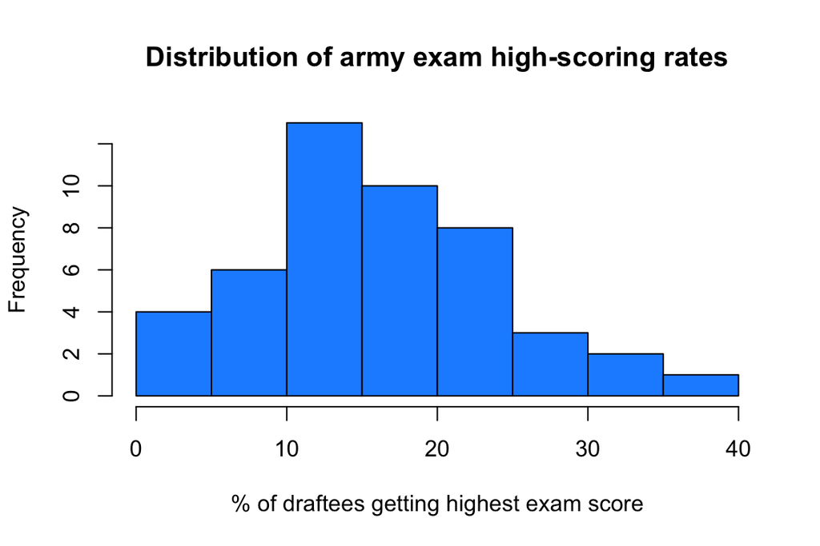